# Airline Delay and Cancellation

Group 5

2022-12-05

Importing data

```r
airlines <- data.frame(read.csv("data/airlines.csv"))
airports <- data.frame(read.csv("data/airports.csv"))
#flights <- data.frame(read.csv("C:/Users/Aditya Kumar/OneDrive/Study/GWU - Data Science/DATS 6101 Intro to Data Science/Project 02/archive (1)/2015.csv"))
#nrow(flights)
```

```r
#set.seed(333)
#sample_size = round(nrow(flights)*0.1)
#flights_sample <- flights[sample(nrow(flights), sample_size, replace = F),]
#head(flights_sample)
```

Exporting smaller sample

```r
#write.csv(flights_sample, file = "data/flights_sample.csv",row.names=F)

flight <- read.csv("data/flights_sample.csv")
```

```r
str(flight)
```

```
## 'data.frame':    581908 obs. of  28 variables:
##  $ FL_DATE            : chr  "2015-02-26" "2015-08-10" "2015-06-10" "2015-01-06" ...
##  $ OP_CARRIER         : chr  "US" "UA" "WN" "HA" ...
##  $ OP_CARRIER_FL_NUM  : int  1812 259 746 313 2609 3440 3721 4375 1795 219 ...
##  $ ORIGIN             : chr  "CLT" "GRR" "ONT" "HNL" ...
##  $ DEST               : chr  "BOS" "ORD" "LAS" "LIH" ...
##  $ CRS_DEP_TIME       : int  2211 1805 1105 1201 1904 1511 855 1301 1445 1812 ...
##  $ DEP_TIME           : int  2233 1856 1106 1152 1858 1513 855 1256 1441 1808 ...
##  $ DEP_DELAY          : int  22 51 1 -9 -6 2 0 -5 -4 -4 ...
##  $ TAXI_OUT           : int  16 12 23 18 12 11 20 10 13 6 ...
##  $ WHEELS_OFF         : int  2249 1908 1129 1210 1910 1524 915 1306 1454 1814 ...
##  $ WHEELS_ON          : int  12 1836 1209 1234 2040 1714 1020 1445 1759 1850 ...
##  $ TAXI_IN            : int  9 33 6 6 15 6 9 11 8 6 ...
##  $ CRS_ARR_TIME       : int  10 1810 1200 1240 2115 1731 1030 1450 1820 1857 ...
##  $ ARR_TIME           : int  21 1909 1215 1240 2055 1720 1029 1456 1807 1856 ...
##  $ ARR_DELAY          : int  11 59 15 0 -20 -11 -1 6 -13 -1 ...
##  $ CANCELLED          : int  0 0 0 0 0 0 0 0 0 0 ...
##  $ CANCELLATION_CODE  : chr  "" "" "" "" ...
##  $ DIVERTED           : int  0 0 0 0 0 0 0 0 0 0 ...
##  $ CRS_ELAPSED_TIME   : int  119 65 55 39 131 80 95 109 155 45 ...
##  $ ACTUAL_ELAPSED_TIME: int  108 73 69 48 117 67 94 120 146 48 ...
##  $ AIR_TIME           : int  83 28 40 24 90 50 65 99 125 36 ...
##  $ DISTANCE           : int  728 137 197 102 604 296 404 542 1009 201 ...
##  $ CARRIER_DELAY      : int  NA 0 0 NA NA NA NA NA NA NA ...
##  $ WEATHER_DELAY      : int  NA 0 0 NA NA NA NA NA NA NA ...
##  $ NAS_DELAY          : int  NA 59 15 NA NA NA NA NA NA NA ...
##  $ SECURITY_DELAY     : int  NA 0 0 NA NA NA NA NA NA NA ...
##  $ LATE_AIRCRAFT_DELAY: int  NA 0 0 NA NA NA NA NA NA NA ...
##  $ Unnamed..27        : logi  NA NA NA NA NA NA ...
```

This data now has 581908 rows.

Now we’ll begin our analysis.

# Pre-processing and initial analysis

Glossary of all the columns in the dataset:

- FL_DATE = Date of the Flight
- OP_CARRIER = Airline Identifier
- OP_CARRIER_FL_NUM = Flight Number
- ORIGIN = Starting Airport Code
- DEST = Destination Airport Code
- CRS_DEP_TIME = Planned Departure Time
- DEP_TIME = Actual Departure Time
- DEP_DELAY = Total Delay on Departure in minutes
- TAXI_OUT = The time duration elapsed between departure from the origin airport gate and wheels off
- WHEELS_OFF = The time point that the aircraft’s wheels leave the ground
- WHEELS_ON = The time point that the aircraft’s wheels touch on the ground
- TAXI_IN = The time duration elapsed between wheels-on and gate arrival at the destination airport
- CRS_ARR_TIME = Planned arrival time
- ARR_TIME = Actual Arrival Time = ARRIVAL_TIME - SCHEDULED_ARRIVAL
- ARR_DELAY = Total Delay on Arrival in minutes
- CANCELLED = Flight Cancelled (1 = cancelled)
- CANCELLATION_CODE = Reason for Cancellation of flight: A - Airline/Carrier; B - Weather; C - National Air System; D - Security
- DIVERTED = Aircraft landed on different airport that the one scheduled
- CRS_ELAPSED_TIME = Planned time amount needed for the flight trip
- ACTUAL_ELAPSED_TIME = AIR_TIME+TAXI_IN+TAXI_OUT
- AIR_TIME = The time duration between wheels_off and wheels_on time
- DISTANCE = Distance between two airports
- CARRIER_DELAY = Delay caused by the airline in minutes
- WEATHER_DELAY = Delay caused by weather
- NAS_DELAY = Delay caused by air system
- SECURITY_DELAY = caused by security reasons
- LATE_AIRCRAFT_DELAY = Delay caused by security

*Source : [kaggle](https://www.kaggle.com/datasets/yuanyuwendymu/airline-delay-and-cancellation-data-2009-2018?select=2009.csv)*

The primary objective of the project is to determine whether a flight is going to be delayed or not, **prior to this information being displayed on the departure board**. Therefore, to define delay, we will look at the column `ARR_DELAY`. If a flight arrives late at its destination, it will be considered as delayed. This is a numeric columns with the time difference in the arrival as minutes. Positive values indicate a delay, while a negative value indicates an early arrival. As first step, we’ll have a look at the distribution of these levels in the dataset as that is an important aspect while training our models.

```r
nrow(subset(flight,ARR_DELAY>0))
```

```
## [1] 208619
```

```r
nrow(subset(flight,ARR_DELAY<=0))
```

```
## [1] 362745
```

We can see that there are more flights that are not delayed than flights that are delayed. This might represent some imbalance in our dataset.

Let’s create a new binary variable `DELAYED_STATUS` to indicate whether a flight was delayed `1` or not delayed `0`

```r
flight$DELAYED_STATUS <- if_else(flight$ARR_DELAY > 0, 1, 0)

table(flight$DELAYED_STATUS)
```

```
##
##      0      1
## 362745 208619
```

From the glossary, we can also identify a few attributes that give a lot of information on whether a flight is going to be delayed. These columns are:

- Taxi Out
- Wheels Off
- Wheels On
- Taxi In
- Actual Elapsed Time

It may not be a good idea to include these attributes during model building as this information is available after the flight takes off from the source airport and is not logical to make use of to predict whether the flight is going to be delayed. To demonstrate this idea, we can build two models - one without these attributes and one with them. The model with these attributes will result in better accuracy, precision and recall.

We can also make a month variable, which could be a good predictor of delays

```r
flight$MONTH <- substr(flight$FL_DATE, 6, 7)
table(flight$MONTH)
```

```
##
##    01    02    03    04    05    06    07    08    09    10    11    12
## 47152 42538 50305 48890 49934 50189 52008 51100 46697 48483 46784 47828
```

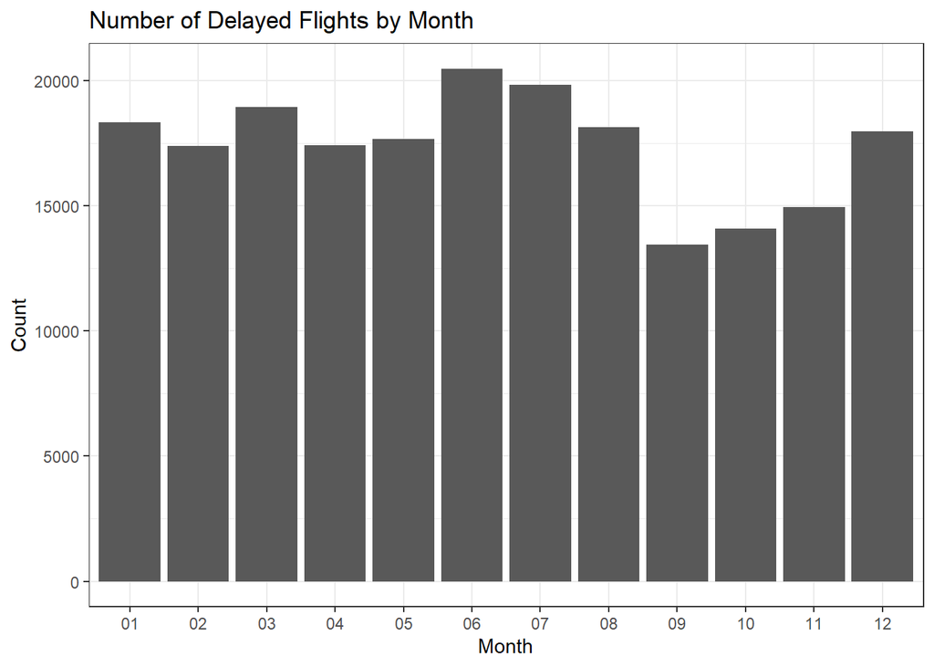

```r
subset(flight,DELAYED_STATUS==1) %>%
  ggplot(
    aes(
      x = MONTH
    )
  ) +
  geom_bar() +
  labs(
    title = "Number of Delayed Flights by Month",
    x = "Month",
    y = "Count"
  ) +
  theme_bw()
```

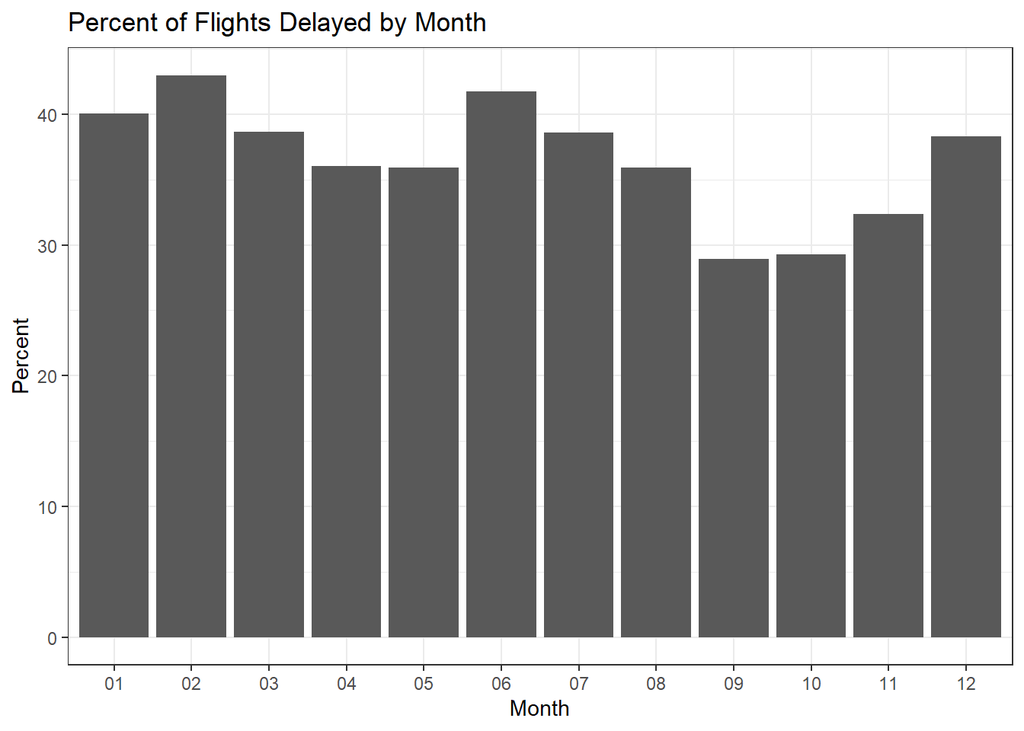

```r
flight %>%
  group_by(MONTH) %>%
  summarize(
    prop_delayed = mean(DELAYED_STATUS, na.rm = T) * 100
  ) %>%
  ggplot(
    aes(
      x = MONTH,
      y = prop_delayed
    )
  ) +
  geom_col() +
  labs(
    title = "Percent of Flights Delayed by Month",
    x = "Month",
    y = "Percent"
  ) +
  theme_bw()
```